# Test a Perceptual Phenomenon

### Analyzing the Stroop Effect

Perform the analysis in the space below. Remember to follow [the instructions](https://docs.google.com/document/d/1-OkpZLjG_kX9J6LIQ5IltsqMzVWjh36QpnP2RYpVdPU/pub?embedded=True) and review the [project rubric](https://review.udacity.com/#!/rubrics/71/view) before submitting. Once you've completed the analysis and write up, download this file as a PDF or HTML file and submit in the final section of this lesson.

(1) What is the independent variable? What is the dependent variable?

The independent variable is the state of congruence. The dependent variable is the time, in seconds.

(2) What is an appropriate set of hypotheses for this task? Specify your null and alternative hypotheses, and clearly define any notation used. Justify your choices.

The null hyposis is the claim: "The mean difference in time between congruent and incongruent test is zero." In other words, the average time it takes to complete the task when the words describe the same color observed is the same as the time it takes when there is a mismatch between the written words and the color observed. **$H_o:\mu_d = 0$**

Here, $H_o $ stands for the null hypothesis, and $\mu_d $ stands for the mean difference between congruent and incongruent values.

The alternative hypotesis is the claim: "The mean difference in time between incongruent and congruent test is greater than zero. In other words, it takes longer to complete the testunder the state of incongruence. **$H_a:\mu_d > 0$**

Here, $ H_a $ stands for the alternative hypotheis, and $\mu_d $ stands for the mean difference between congruent and incongruent values.

(3) Report some descriptive statistics regarding this dataset. Include at least one measure of central tendency and at least one measure of variability. The name of the data file is 'stroopdata.csv'.

```python
import pandas as pd
import matplotlib.pyplot as pltdd
from scipy import stats
import csv
import os

dataset = pd.read_csv('stroopdata.csv')
#dataset.describe()
dFrame = pd.DataFrame(dataset)
#add new column for paired difference
pairedDiff = dataset['Incongruent'] - dataset['Congruent']
dFrame['Paired Difference']= pairedDiff
print(dFrame['Paired Difference'])
dFrame['Paired Difference'].describe()
```

```
0      7.199
1      1.950
2     11.650
3      7.057
4      8.134
5      8.640
6      9.880
7      8.407
8     11.361
9     11.802
10     2.196
11     3.346
12     2.437
13     3.401
14    17.055
15    10.028
16     6.644
17     9.790
18     6.081
19    21.919
20    10.950
21     3.727
22     2.348
23     5.153
Name: Paired Difference, dtype: float64
```

```
count    24.000000
mean      7.964792
std       4.864827
min       1.950000
25%       3.645500
50%       7.666500
75%      10.258500
max      21.919000
Name: Paired Difference, dtype: float64
```

$$\bar x = 7.9648 \: $$ $$ \sigma = 4.8648 \: $$

(4) Provide one or two visualizations that show the distribution of the sample data. Write one or two sentences noting what you observe about the plot or plots.

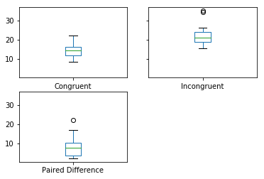

```
Paired Difference    AxesSubplot(0.125,0.125;0.775x0.755)
dtype: object
```

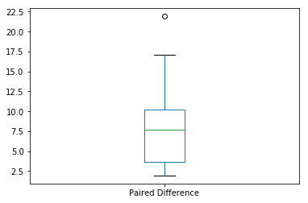

```python
dataset.plot(kind = 'box', subplots = True, layout=(2,2), sharex=True, sharey=True)
pltdd.show()
dFrame['Paired Difference'].plot(kind = 'box', subplots = True, layout = (1,1))
```

From the boxplots (Congruent and Incongruent)we notice that the lowest time of execution under incongruent state seems to match the upper quartile of the execution under congruent state. We also notice two outliers on the plot for incongruent state. There is an outlier on Paired Difference.

(5) Now, perform the statistical test and report your results. What is your confidence level or Type I error associated with your test? What is your conclusion regarding the hypotheses you set up? Did the results match up with your expectations? **Hint:** Think about what is being measured on each individual, and what statistic best captures how an individual reacts in each environment.

```
Ttest_relResult(statistic=8.020706944109957, pvalue=4.1030005857111781e-08)
```

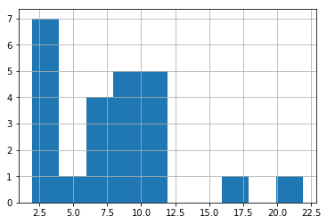

```python
#In this case, we have pair of results from each individual We find convenient two use a one-sample procedure.
#We will find the difference in time between the incongruent and the congruent test for each individual.
#If the null hypothesis is true, we should get a mean value of approximately zero for the paired differences.
#Create dataframe
import pandas as pd
from scipy import stats
import csv
import os
dataset = pd.read_csv('stroopdata.csv')
dFrame = pd.DataFrame(dataset)
#add new column for paired difference
pairedDiff = dataset['Incongruent']- dataset['Congruent']
dFrame['Paired Difference']=pairedDiff
#print(dFrame)
dFrame.describe()
dFrame['Paired Difference'].describe()
dFrame['Paired Difference'].hist()
#pltdd.show()
#From the histogram we observe that the distribution does not look normal (it should).
#But t procedures are robust.
#Also, the observations should be independent from each other, and they are.
stats.normaltest(dFrame['Paired Difference'])
stats.ttest_rel(dataset['Incongruent'], dataset['Congruent'], axis=0, nan_policy='propagate')
```

We have to determine whether a mean increase of 7.9648 is large enough for us to discard the null hypotesis. The mean difference is 7.9648, the standard deviation is 4.8648, and n = 24. The one-sample t statistic is : $$t =\left(\frac{\bar x -0}{\left(\frac{s}{\sqrt{n}}\right)}\right)$$ $$t = \left(\frac{7.9648-0}{\left(\frac{4.8648}{\sqrt{24}}\right)}\right)$$ => $$t = \left(\frac{7.9648}{0.9928}\right)$$ => $$ t = 8.0224$$ , df = 24-1 = 23, p = 0.00000004103.

(6) Optional: What do you think is responsible for the effects observed? Can you think of an alternative or similar task that would result in a similar effect? Some research about the problem will be helpful for thinking about these two questions!

Instinctively we tend to read the words and an image is created in our brains, later we determine the name of the color shown in the test, the brain spends additional time trying to identify an error. I would like to investigate whether the effect is affected by the age of the subjects. An alternative experiment would be: to assign the task to determine which has the greater value between two numbers. In one test both numbers appear with the same font-size and in the second test of the same subject the smallest number is written with a much larger font-size than the largest number.